# Project 2: Exploratory Data Analysis

Meenakshi Nerolu

June 23, 2019

In statistics, exploratory data analysis **(EDA)** is an approach to analyzing data sets to summarize their main characteristics, often with visual methods.

Now We will take one example to analyze the data set graphically. Consider information on population, region, area size, infant mortality and others from different countries of the world. All these data sets are made up of data from the US government (https://www.kaggle.com/fernandol/countries-of-the-world).

#### Reading the csv file that contains the data information and store it in the variable “countries” :

```r
countries <- read.csv(file = "countries_world.csv",stringsAsFactors = FALSE)
#dimension of 'countries'
dim(countries)
```

```
## [1] 227  20
```

```r
#structure of 'countries'
str(countries)
```

```
## 'data.frame':    227 obs. of  20 variables:
##  $ Country                         : chr  "Afghanistan " "Albania " "Algeria " "American Samoa " ...
##  $ Region                          : chr  "ASIA (EX. NEAR EAST)         " "EASTERN EUROPE                     " "NORTHERN AFRICA                    " "OCEANIA                            " ...
##  $ Population                      : int  31056997 3581655 32930091 57794 71201 12127071 13477 69108 39921833 2976372 ...
##  $ Area                            : int  647500 28748 2381740 199 468 1246700 102 443 2766890 29800 ...
##  $ Pop_Density                     : num  48 124.6 13.8 290.4 152.1 ...
##  $ Coastline_.coast.area.ratio.    : num  0 1.26 0.04 58.29 0 ...
##  $ Net_migration                   : num  23.06 -4.93 -0.39 -20.71 6.6 ...
##  $ Infant_mortality_per_1000_births: num  163.07 21.52 31 9.27 4.05 ...
##  $ GDP_per_capita                  : int  700 4500 6000 8000 19000 1900 8600 11000 11200 3500 ...
##  $ Literacy                        : num  36 86.5 70 97 100 42 95 89 97.1 98.6 ...
##  $ Phones_per_1000                 : num  3.2 71.2 78.1 259.5 497.2 ...
##  $ Arable_percent                  : num  12.13 21.09 3.22 10 2.22 ...
##  $ Crops_percent                   : num  0.22 4.42 0.25 15 0 0.24 0 4.55 0.48 2.3 ...
##  $ Other_percent                   : num  87.7 74.5 96.5 75 97.8 ...
##  $ Climate                         : num  1 3 1 2 3 NA 2 2 3 4 ...
##  $ Birthrate                       : num  46.6 15.11 17.14 22.46 8.71 ...
##  $ Deathrate                       : num  20.34 5.22 4.61 3.27 6.25 ...
##  $ Agriculture                     : num  0.38 0.232 0.101 NA NA 0.096 0.04 0.038 0.095 0.239 ...
##  $ Industry                        : num  0.24 0.188 0.6 NA NA 0.658 0.18 0.22 0.358 0.343 ...
##  $ Service                         : num  0.38 0.579 0.298 NA NA 0.246 0.78 0.743 0.547 0.418 ...
```

```r
# loading 'dplyr' package
library(dplyr)
#Omit the rows that contain NA's
new_country_dat <- na.omit(countries)
#Dimension of the new data set
dim(new_country_dat)
```

```
## [1] 179  20
```

```r
#Top of the data
dim(head(new_country_dat[, c(1:3)]))
```

```
## [1] 6 3
```

```r
#Bottom of the data
tail(new_country_dat[, c(1:3)])
```

```
##        Country                              Region Population
## 218   Vanuatu  OCEANIA                                 208869
## 219 Venezuela              LATIN AMER. & CARIB       25730435
## 220   Vietnam        ASIA (EX. NEAR EAST)            84402966
## 225     Yemen  NEAR EAST                             21456188
## 226    Zambia  SUB-SAHARAN AFRICA                    11502010
## 227  Zimbabwe  SUB-SAHARAN AFRICA                    12236805
```

```r
#select(new_country_dat, Country) %>% unique %>% nrow
#unique(new_country_dat$Country
```

## Exploratory Graphics

To communicate information clearly and efficiently, data visualization uses statistical graphics, plots, information graphics and other tools. For data visualization we can use the following graphical packages :

- Boxplot
- Barplot
- Histogram
- Scatterplot

### Boxplot

Boxplots are a visual representation of the five-number summary plus a bit more information. In particular, boxplots commonly plot outliers that go beyond the bulk of the data. This is implemented via the `boxplot()` function.

**Five-number summary** is a set of descriptive statistics that provide information about a dataset. It consists of the five most important sample percentiles:

- the sample minimum (smallest observation),
- the lower quartile or first quartile (Q1),
- the median (the middle value),
- the upper quartile or third quartile (Q3),
- the sample maximum (largest observation).

```r
#five_number summary
fivenum(new_country_dat$Literacy)
```

```
## [1]  17.60  69.95  90.90  97.80 100.00
```

```r
summary(new_country_dat$Literacy)
```

```
##    Min. 1st Qu.  Median    Mean 3rd Qu.    Max.
##   17.60   69.95   90.90   81.94   97.80  100.00
```

```r
#standard deviation
sd(new_country_dat$Literacy, na.rm = TRUE)
```

```
## [1] 19.83754
```

```r
#interquartile range
IQR(new_country_dat$Literacy, na.rm = TRUE)
```

```
## [1] 27.85
```

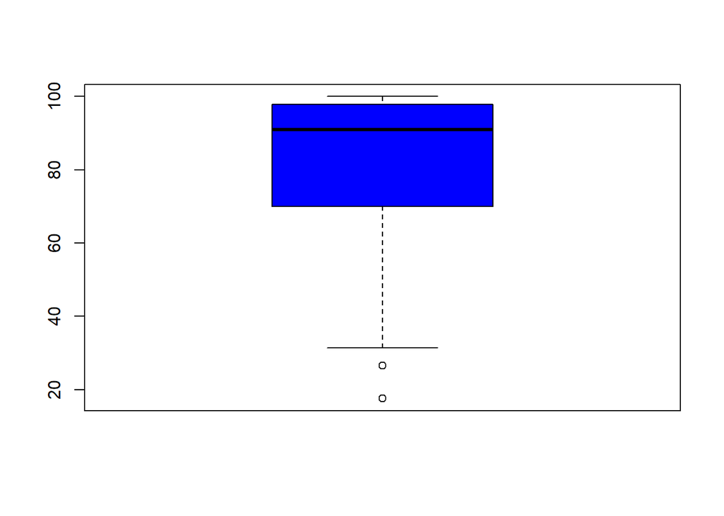

```r
#Boxplot
boxplot(new_country_dat$Literacy, col="blue")
```

#### Understanding boxplot

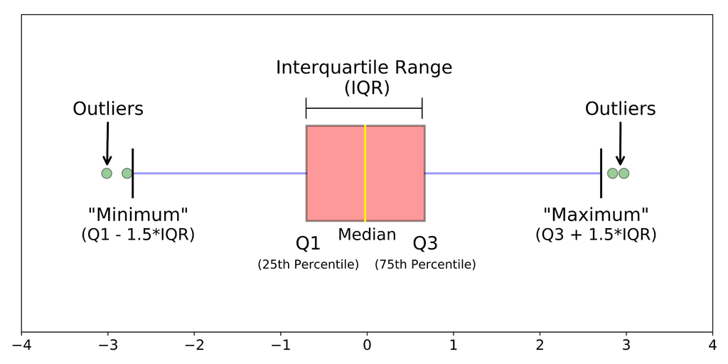

Different parts of boxplot

A boxplot is a standardized way of displaying the distribution of data based on a five number summary (“minimum”, first quartile (Q1), median, third quartile (Q3), and “maximum”). It can tell you about your outliers and what their values are. It gives us a good indication of how the values in the data are spread out.

### Barplot

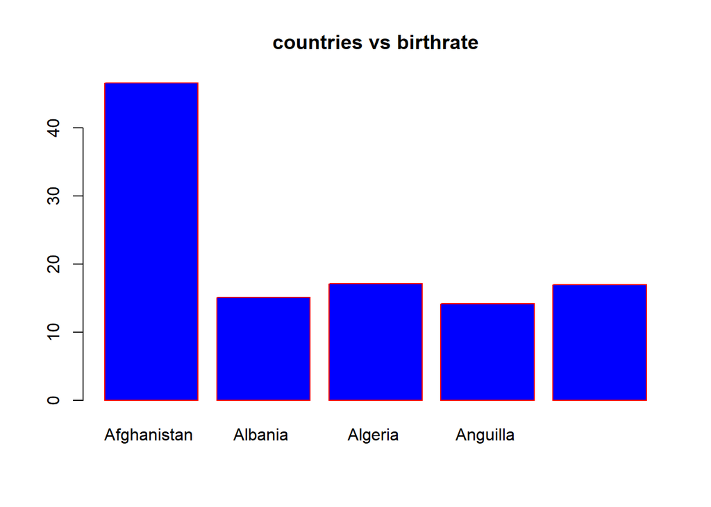

Example 1: Barplot

```r
#Bar plot for birthrate for first 10 countries in the world
#library(tidyr)
subset_barplot_x <- head(c(new_country_dat$Birthrate),5)
subset_barplot_y <- head(c(new_country_dat$Country),5)
barplot(subset_barplot_x, names.arg=subset_barplot_y, main = "countries vs birthrate", col = "blue", border ="red")
```

Thus basic syntax to create a bar-chart in `R` is: `barplot(H,xlab,ylab,main,names.arg,col)`, where

- **H** : vector or matrix containing numeric values used in bar chart
- **xlab** : label for x-axis
- **ylab** : label for yaxis
- **main** : title of the bar chart
- **names.arg** : vector of names appearing under each bar
- **col** : give colors to the bars in the graph

#### Stacked Barplot

We can create bar chart with groups of bars and stacks in each bar by using a matrix as input values.

[figure not shown]

Example 2: Stacked Barplot

```r
#Group barplot
# Create the input vectors.
#library(tidyverse)
subset_stack_barplot <- table(new_country_dat$Birthrate, new_country_dat$Climate)
barplot(subset_stack_barplot, main = "Climate Vs Birthrate", col=c("blue", "red"))
legend("topleft", c("birthdate","Climate"), fill=c("blue","red"), cex=1.3)
```

### Histogram

A histogram is a visual representation of the distribution of a dataset.It is an estimate of the probability distribution of a continuous variable. The histogram can be made with the `hist()` function.

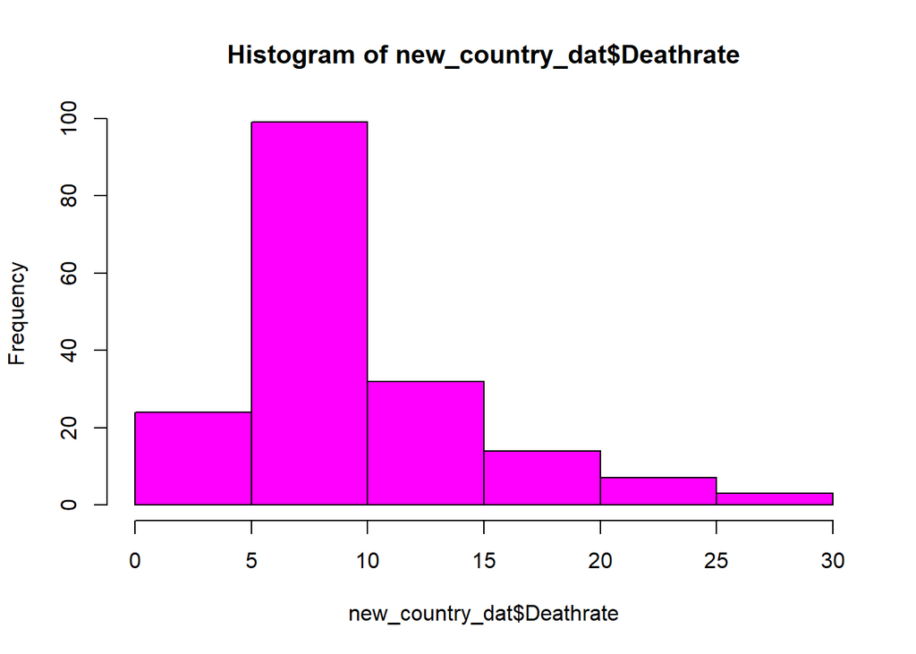

Histogram

```r
hist(new_country_dat$Deathrate, col ="magenta")
```

### Scatter Plot

A scatter plot is a two-dimensional data visualization that uses dots to represent the values obtained for two different variables - one plotted along the x-axis and the other plotted along the y-axis. A scatter plot can be created using the function `plot()`.

[figure not shown]

```r
x <- new_country_dat$Deathrate
y <- new_country_dat$Birthrate
# Plot with main and axis titles
plot(x, y, main = "Birthrate vs Deathrate",
     xlab = "Birthrate", ylab = "Deathrate",
      frame = FALSE)
```

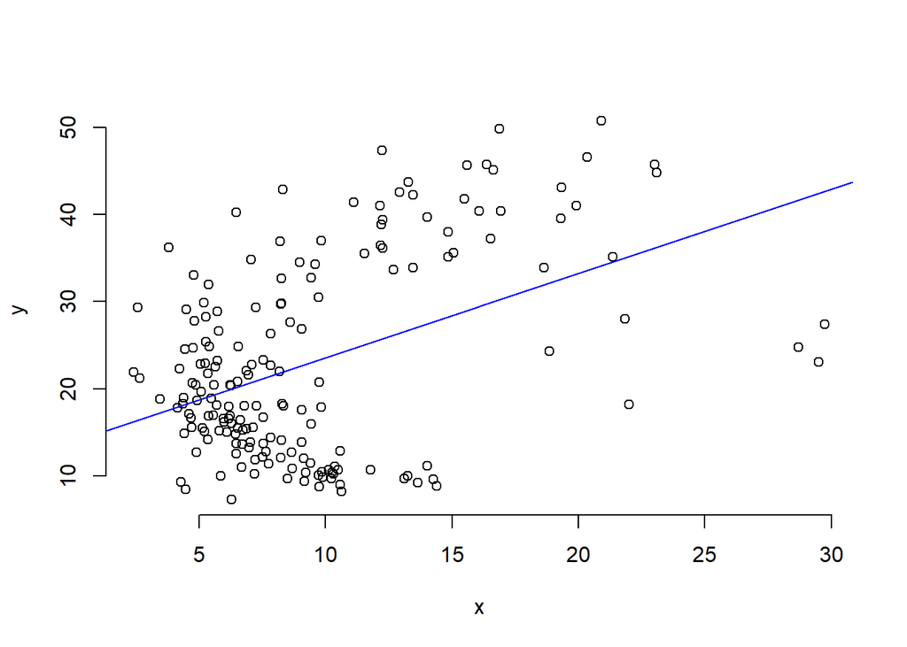

```r
# Add regression line
plot(x, y, frame = FALSE)
abline(lm(y ~ x, data = new_country_dat), col = "blue")
```

## ggplot2

ggplot2 is a data visualization package for the statistical programming language `R`.

### Understanding `ggplot` syntax:

`ggplot` works with dataframes and not individual vectors. All the data needed to make the plot is typically be contained within the dataframe supplied to the `ggplot()` itself or can be supplied to respective geoms. Let’s initialize a basic `ggplot`.

```r
library(tidyverse)
```

```r
library(ggplot2)
```

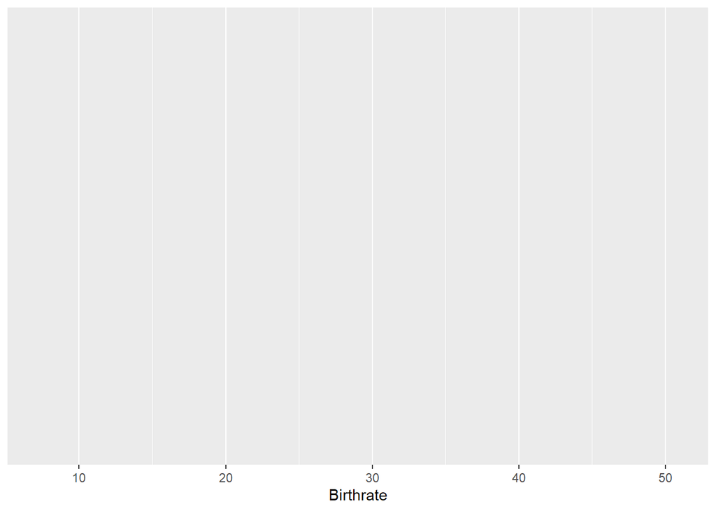

```r
ggplot(new_country_dat, aes(x = Birthrate)) # Birthrate is a column in 'new_country_dat'
```

Also note that `aes()` function is used to specify the `X` and `Y` axes.

The `aes` argument stands for aesthetics. `ggplot2` considers the X and Y axis of the plot to be aesthetics as well, along with color, size, shape, fill etc. If you want to have the color, size etc fixed, you need to specify it outside the `aes()`, like this:

```r
#ggplot(new_country_dat, aes(x=Birthrate), color="steelblue")
```

### Layers:

The layers in `ggplot2` are also called *‘geoms’*. Once the base setup is done, you can append the geoms one on top of the other. Following are some of the available list of *geoms*

- **`geom_point()`**,
- **`geom_smooth()`**,
- **`geom_histogram()`**,
- **`geom_boxplot()`**,
- **`geom_bar()`** etc.

### Scatter Plot

We can plot scatter plot using a geom layer called **`geom_point`**. For example,

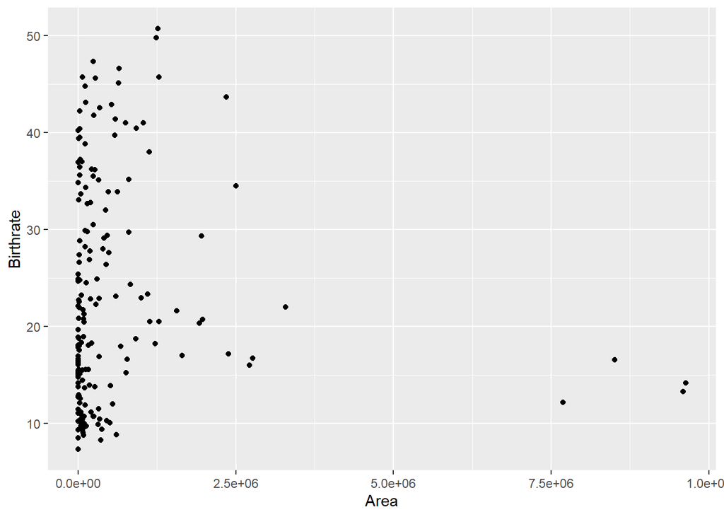

Scatter plot

```r
ggplot(new_country_dat, aes(x=Area, y = Birthrate)) + geom_point()
```

Now we add a smoothing layer using **`geom_smooth`**

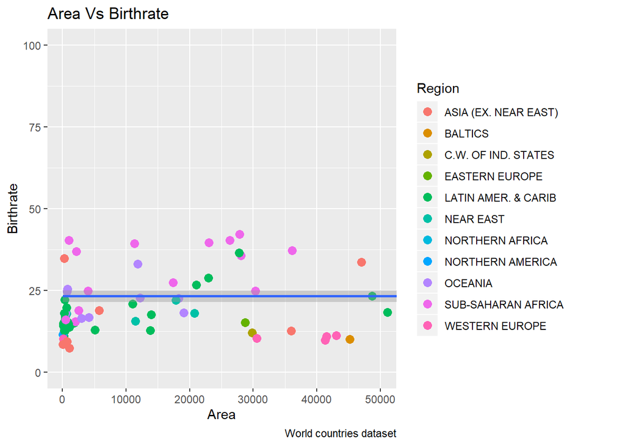

```r
ggplot(new_country_dat, aes(x=Area, y=Birthrate)) +
  geom_point(aes(col=Region), size=3) +  # Set color to vary based on state categories.
  geom_smooth(method="lm") +
  coord_cartesian(xlim=c(100, 50000), ylim=c(0, 100)) +
  labs(title="Area Vs Birthrate", y="Birthrate", x="Area", caption="World countries dataset")
```

where `lm` represents linear model and it draws the line of best fit.

#### **`geom_histogram()`**

Histograms (**`geom_histogram()`**) display the counts with bars.

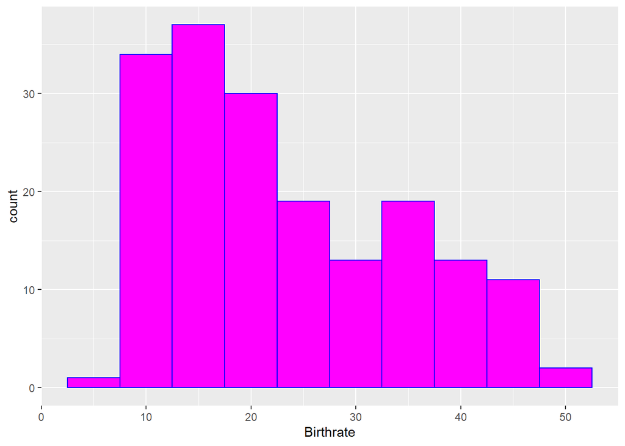

Histogram

```r
ggplot(new_country_dat, aes(x = Birthrate)) + geom_histogram( binwidth = 5, fill = "magenta", color = "blue")
```

```r
library(grid)
library(gridExtra)
```

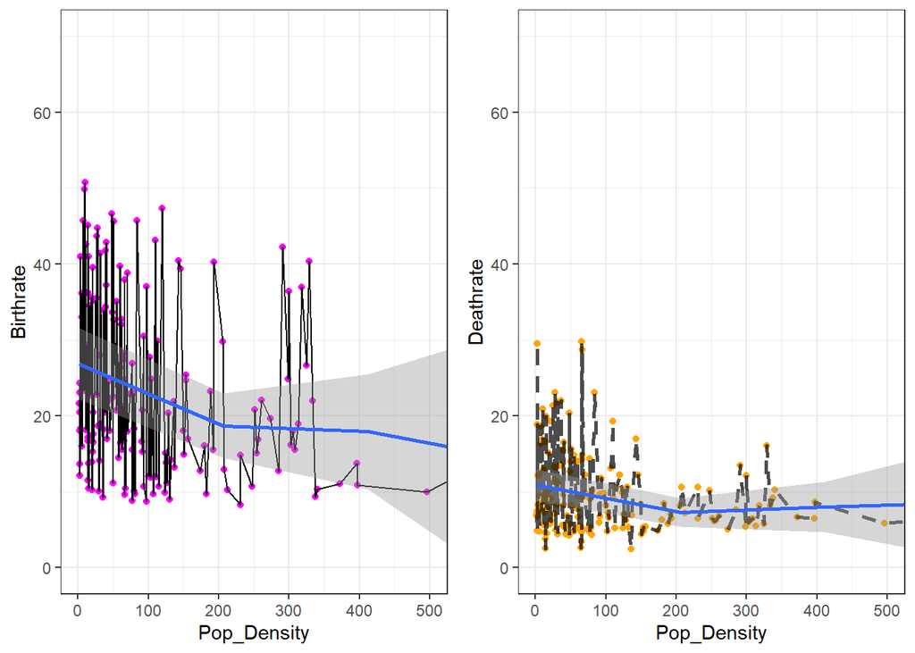

```r
ggplot(new_country_dat, aes(x=Pop_Density, y = Birthrate)) + geom_point(size = 1.5,colour='magenta')+geom_line()+stat_smooth()+theme_bw()+coord_cartesian(xlim=c(0, 500), ylim=c(0, 70))->g1

ggplot(new_country_dat, aes(x=Pop_Density, y = Deathrate)) + geom_point(size = 1.5,colour='orange')+geom_line(size=1,alpha=0.7,linetype=2)+stat_smooth()+theme_bw()+coord_cartesian(xlim=c(0, 500), ylim=c(0, 70))->g2
grid.arrange(g1, g2, ncol = 2)
```

#### **`geom_boxplot()`**

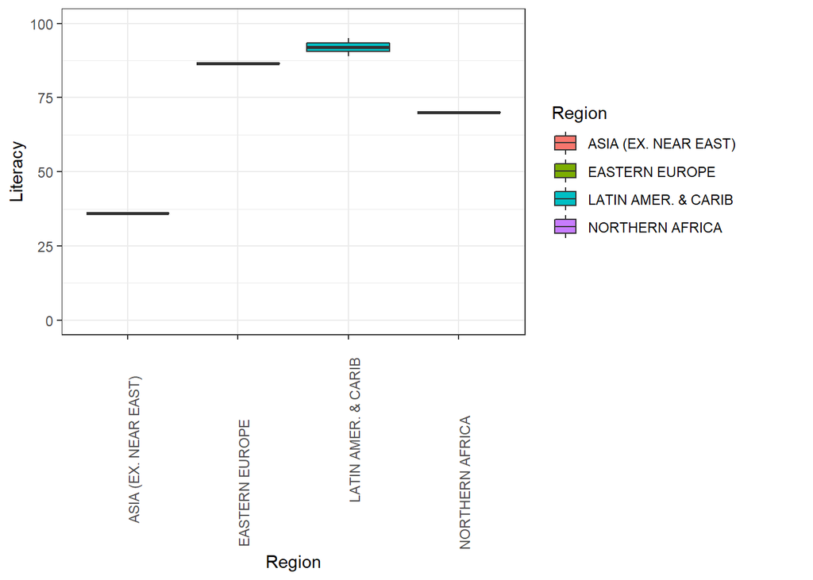

```r
new_country_dat_subset <- head(new_country_dat,5)
ggplot(new_country_dat_subset, aes(x=Region,y= Literacy))+geom_boxplot(aes(fill= Region)) +theme_bw()+coord_cartesian(ylim=c(0, 100))+theme(axis.text.x = element_text(angle = 90,hjust=1))
```